# Modeling cell type colocalization in multiplex imaging data using functional regression and wild bootstrap

Carly Middleton, Qi Zheng, Jun Yan, Susmita Datta, Maiying Kong

26 April 2026

This vignette introduces the R package `funboot`. In the following, we demonstrate how to 1.) use in-package functions to preprocess single-cell spatial data, 2.) compute spatial summary functions and colocalization curves for pairs of cell types, and 3.) quantify colocalization as a function of patient-level and spatial covariates, using the concurrent functional regression framework and our wild bootstrap-based inference procedure.

We illustrate this workflow by reproducing our manuscript’s real data analyses of the publicly available [Jackson-Fischer breast cancer](https://bodenmillergroup.github.io/imcdatasets/reference/JacksonFischer_2020_BreastCancer.html) and [Hoch-Schulz melanoma](https://bodenmillergroup.github.io/imcdatasets/reference/HochSchulz_2022_Melanoma.html) imaging mass cytometry datasets.

Although a minimum of `B1 = 50` outer and `B2 = 50` inner bootstrap samples and `n_perm = 50` to `100` permuted spatial summary functions are generally recommended in practice, this vignette uses `B1 = B2 = 10` and `n_perm = 5` to reduce computation time.

## Installation

The package’s dependencies are below.

```r
library(mgcv)
library(refund)
library(spatstat.geom)
library(spatstat.explore)
library(ggplot2)
```

`funboot` can be installed and loaded as follows:

```r
devtools::install_github("carlyemiddleton/funboot", build_vignettes = TRUE)
```

```r
library(funboot)
```

Though not a package dependency, we also use `patchwork` within the vignette to assist with plotting:

```r
library(patchwork)
```

## Breast Cancer Data

The 100-image subset of the Jackson-Fischer data contains 1 image per subject. It is stored in-package and can be loaded as follows:

```r
data("breastcancer_data", package="funboot")
```

**Visualization**

We focus on cell metaclusters 3 (T cells), 7 (endothelial cells), 9 (small circular stromal cells), and 16 (proliferative epithelial cells) from the Jackson-Fischer paper. For simplicity, we refer to these metaclusters as cell types. Their spatial distributions can be examined using `funboot::plot_images()`:

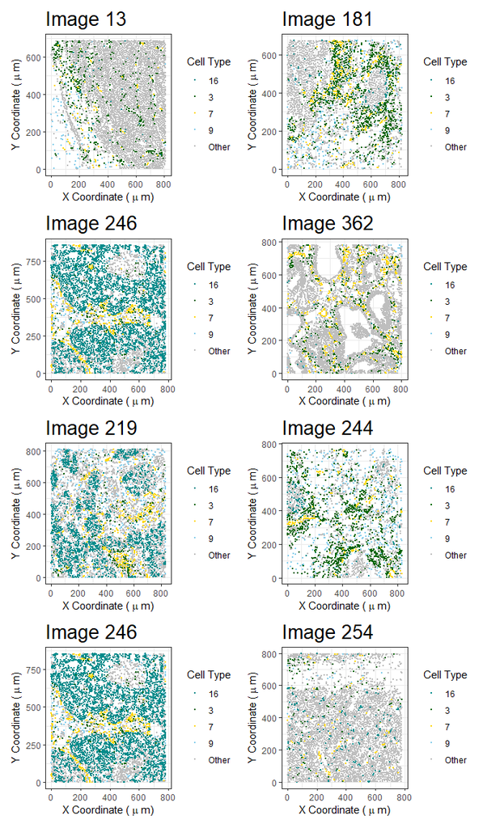

**Figure 1.** Spatial distributions of selected cell types in representative images from the breast cancer dataset.

```r
## Choose colors for each cell type
palette <- c(
  "Other" = "gray",
  "7" = "gold",
  "3" = "darkgreen",
  "9" = "skyblue",
  "16" = "cyan4"
)

## Plot the images featured in the manuscript
plot_list <- funboot::plot_images(
  data = breastcancer_data,
  images_to_plot = c(13, 181, 246, 362, 219, 244, 246, 254),
  cell_types_to_plot = c(7, 3, 9, 16),
  palette = palette
)

## Each entry of plot_list corresponds to one of images_to_plot
(plot_list[[1]] + plot_list[[2]]) /
(plot_list[[3]] + plot_list[[4]]) /
(plot_list[[5]] + plot_list[[6]]) /
(plot_list[[7]] + plot_list[[8]])
```

Cell types 7 (endothelial cells) and 3 (T cells) appear to be colocalized. We can examine their colocalization curve by fitting the model

$$Y_{i}(r) = \beta_0(r) + \epsilon_i(r), \qquad i = 1, \ldots, n,$$
where $Y_{i}(r)$ denotes the observed colocalization curve for T cells around endothelial cells within the image belonging to subject $i$. We can then perform inference on $\mathbb{E}[Y(r)]$ by calculating a confidence band for the intercept function $\beta_0(r)$.

**Data Preprocessing**

The first step is to preprocess the data and then calculate the observed and expected $L-$ function for each image. The first preprocessing step is to discard images with sparse cell counts; in this step, we exclude images with 20 cells or less of either type. Then, because some of the images may contain missing tissue regions, we estimate the expected value of the spatial summary function under complete spatial randomness in each image using a [permutation adjustment](https://journals.plos.org/ploscompbiol/article?id=10.1371/journal.pcbi.1009900). We calculate each image’s observed colocalization curve by subtracting this expected value from the observed value of the spatial summary function in each image.

To capture the full range of spatial structure evident in the data, we calculate the summary functions across a grid ranging from `0` to `500` micrometers with increments of `1`, as the colocalization curves generally approached 0 after this range. The entire process is carried out using `funboot::preprocess_data()`.

```r
set.seed(12345)

sumfun_data_interaction <- funboot::preprocess_data(
  data = breastcancer_data,
  from_cell = 7,              # Endothelial cells
  to_cell = 3,                # T cells
  qc_cellcount_cutoff = 20,
  n_perm = 5,
  perm_yn = TRUE,
  r_max = 500,
  inc = 1,
  image_dims = c(0, 1000, 0, 1000),
  summary_function = "L"
)
```

**Inference Procedure**

From the preprocessed summary function data, we can construct a confidence band for $\beta_0(r)$, using the function `funboot::wildBS_CB()`. Within this function, we let `formula = outcome ~ 1` to represent the intercept-only model. `funboot::wildBS_CB()` fits the specified functional regression model using `refund::pffr()` and then obtains the desired confidence band by applying the wild bootstrap-based inference procedure described in our manuscript.

`funboot::wildBS_CB()` uses three arguments to define the target curve, $\theta(r)$, for which inference is performed: `target`, `form`, and `func`. The character vector `target` describes which model components make up $\theta(r)$. Specifically, each element of `target` must equal `"Intercept"` or the name of a model covariate as it appears in the dataset supplied to `funboot::preprocess_data()`.

`form` is a character vector whose elements correspond in order to each element of `target`. The elements of `form` can be either `"term"` (indicating an entire model term $\beta(r)X(r)$) or `"coef"` (indicating just the coefficient $\beta(r)$), depending on how each corresponding component of `target` enters $\theta(r)$.

Finally, `func` accepts a function describing how each model component is combined to form $\theta(r)$. It is written as a linear combination of the elements of `target`.

To perform inference on the intercept function $\beta_0(r)$, we set the target curve to $\theta(r) = \beta_0(r)$. We do this by specifying `target = c("Intercept")`, `form = c("coef")`, and `func = function(Intercept){Intercept}`. `B1` and `B2` represent the number of outer and inner bootstrap samples to be used, respectively, `alpha` represents the desired significance level of the confidence band, and `id` represents the name of the patient ID variable.

```r
CB_interaction <- funboot::wildBS_CB(
  formula = outcome ~ 1,
  data = sumfun_data_interaction,
  target = c("Intercept"),
  form = c("coef"),
  func = function(Intercept) {
    Intercept
  },
  B1 = 10,
  B2 = 10,
  alpha = 0.05,
  id = "patient_id"
)
```

The resulting confidence band, as well as the estimated target curve yielded by `pffr()`, can be plotted using `funboot::plot_wildBS_CB()`. Here we overlay them with each image’s observed $Y(r)$:

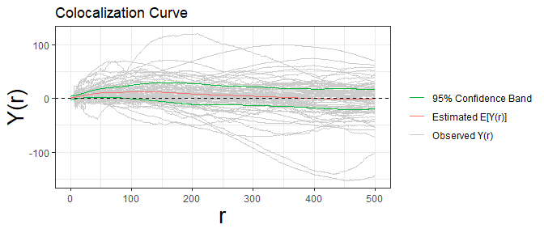

**Figure 2.** Estimated colocalization curve with confidence band for T cells around endothelial cells.

```r
## Base plot
p <- funboot::plot_wildBS_CB(CB_interaction)

## Layer for the image-specific curves
bg_df <- data.frame(
  r = sumfun_data_interaction$r,
  y = sumfun_data_interaction$outcome,
  curve = sumfun_data_interaction$image_number
)

bg_layer <- geom_line(
  data = bg_df,
  aes(x = r, y = y, group = curve, color = "Observed Y(r)"),
  inherit.aes = FALSE,
  linewidth = 0.3
)

## Combine both layers and add formatting
p$layers <- c(list(bg_layer), p$layers)

p +
  ggtitle("Colocalization Curve") +
  labs(
    x = "r",
    y = "Y(r)"
  ) +
  scale_color_manual(
    values = c(
      "Observed Y(r)" = "gray80",
      "Confidence Band" = "#00BA38",
      "Estimated Target Curve" = "#F8766D"
    ),
    labels = c(
      "Observed Y(r)" = "Observed Y(r)",
      "Estimated Target Curve" = "Estimated E[Y(r)]",
      "Confidence Band" = "95% Confidence Band"
    ),
    breaks = c(
      "Confidence Band",
      "Estimated Target Curve",
      "Observed Y(r)"
    )
  )
```

**Adding Covariates**

Covariates can be incorporated into the above model. We assess the effects of patient age, tumor grade, and the $L-$ curve $\widehat{L}^{Endo,Endo}(r)$, which describes the level of spatial self-coupling of endothelial cells within the images, on the colocalization curve. Treating tumor grade as a categorical covariate with grade 1 as the reference level yields the model

$$Y_i(r) = \beta_0(r) + \beta_1(r)x_{iage} + \beta_2(r)x_{igrade2} +
\beta_3(r)x_{igrade3} + \beta_4(r)\widehat{L}_{i}^{Endo,Endo}(r) +
\epsilon_i(r).$$
$\widehat{L}_{i}^{Endo,Endo}(r)$ is a spatial covariate. To include it in the model, we calculate its observed value in each image using `funboot::preprocess_data()`, and merge the results into the previous dataset:

```r
## Compute \hat{L}_{Endo,Endo}(r)
spatial_cov_data <- funboot::preprocess_data(
  data = breastcancer_data,
  from_cell = 7,              # Endothelial cells
  to_cell = 7,                # Endothelial cells
  qc_cellcount_cutoff = 20,
  n_perm = 5,
  perm_yn = TRUE,
  r_max = 500,
  inc = 1,
  image_dims = c(0, 1000, 0, 1000),
  summary_function = "L"
)

## Get previous dataset and prepare for merge
sumfun_data_covariates <- sumfun_data_interaction
names(spatial_cov_data)[names(spatial_cov_data) == "L_obs"] <- "spatial_cov"
spatial_cov_data <- spatial_cov_data[,!names(spatial_cov_data) %in% c("L_expect", "L_pmean","outcome")]
sumfun_data_covariates$patient_id <- as.factor(sumfun_data_covariates$patient_id)
spatial_cov_data$patient_id <- as.factor(spatial_cov_data$patient_id)

## Merge and sort the results
sumfun_data_full_covariates <- merge(
  sumfun_data_covariates,
  spatial_cov_data,
  by = c(
    "image_number",
    "r",
    "patient_id",
    "patient_age",
    "tumor_grade"
  ),
  all = FALSE
)
sumfun_data_full_covariates <- sumfun_data_full_covariates[
  order(
    sumfun_data_full_covariates$image_number,
    sumfun_data_full_covariates$r
  ),
]
```

From the merged dataset, indicator variables are constructed to represent the tumor grade covariate:

```r
sumfun_data_full_covariates$grade2 <- as.integer(
  sumfun_data_full_covariates$tumor_grade == "2"
)

sumfun_data_full_covariates$grade3 <- as.integer(
  sumfun_data_full_covariates$tumor_grade == "3"
)
```

We then use `funboot::wildBS_CB()` to fit the model with covariates and demonstrate the test of the significance of $\beta_4(r)$.

If spatial covariates are included in the model statement, they must be specified explicitly. Here, $\widehat{L}_{i}^{Endo,Endo}(r)$, named in the dataset as `spatial_cov`, is specified as a spatial covariate by setting `spatial_covars = c("spatial_cov")`.

By setting `target = c("spatial_cov")`, `form = c("coef")`, and `func = function(spatial_cov){spatial_cov}`, we obtain a 95% confidence band for $\beta_4(r)$:

```r
CB_beta4 <- funboot::wildBS_CB(
  formula = outcome ~ patient_age + grade2 + grade3 + spatial_cov,
  data = sumfun_data_full_covariates,
  spatial_covars = c("spatial_cov"),
  target = c("spatial_cov"),
  form = c("coef"),
  func = function(spatial_cov) {
    spatial_cov
  },
  B1 = 10,
  B2 = 10,
  alpha = 0.05,
  id = "patient_id"
)
```

From the confidence band, the p-value for the test of $\beta_4(r) = 0$ is calculated as follows:

```r
M <- max(abs((CB_beta4$target_curve_estimates - 0)/CB_beta4$target_curve_SEs))
mean(CB_beta4$M > M) #p-value
```

```
#> [1] 0
```

Because $p < .05$, the conclusion from this test is that spatial self-coupling patterns of endothelial cells significantly influence the degree of colocalization of T cells around endothelial cells (though again, more bootstrap samples are needed for accurate results).

## Melanoma Data

Next, we load the in-package melanoma dataset:

```r
data("melanoma_data", package="funboot")
```

**Visualization**

This analysis focuses on the spatial relationships between CD8- T cells, CD8+ T cells, and vasculature cells. We plot representative images as follows:

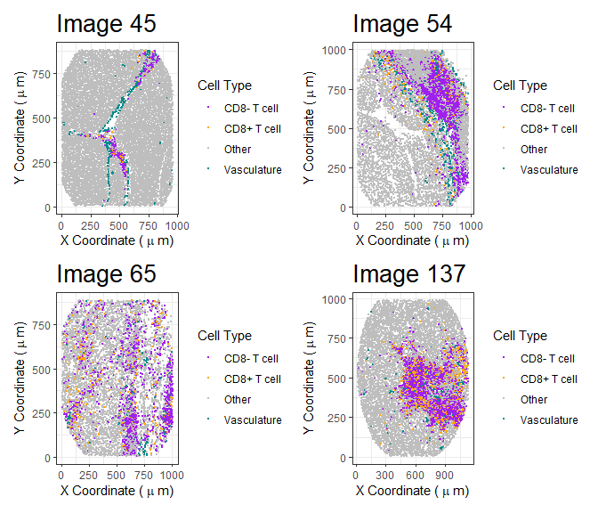

**Figure 3.** Spatial distributions of selected cell types in representative images from the melanoma dataset.

```r
## Choose colors for each cell type
palette <- c(
  "Other" = "gray",
  "CD8- T cell" = "purple",
  "CD8+ T cell" = "orange",
  "Vasculature" = "cyan4"
)

## Plot the images featured in the manuscript
plot_list <- funboot::plot_images(
  data = melanoma_data,
  images_to_plot = c(45, 54, 65, 137),
  cell_types_to_plot = c("CD8- T cell", "CD8+ T cell", "Vasculature"),
  palette = palette
)

## Each entry of plot_list corresponds to one of images_to_plot
(plot_list[[1]] + plot_list[[2]]) /
(plot_list[[3]] + plot_list[[4]])
```

**Modeling Colocalization in the Overall Image**

We first assess the colocalization of CD8+ T cells around CD8- T cells across the full image area, using the model

$$Y_{ik}(r) = \beta_0(r) + b_{0i}(r) + \epsilon_{ik}(r), \qquad i = 1,
\ldots, n, \qquad k = 1, \ldots, K_i.$$
Because the dataset contains multiple images per patient, we include a functional random intercept, $b_{0i}(r)$, to account for within-patient correlation. In the above, $i$ indexes patients and $k$ indexes images within patients.

The functional random intercept for the variable `patient_id` is specified in the `formula` argument as `s(patient_id, bs = "re")`, following the `pffr()` syntax for functional random intercepts. Additionally, `re = patient_id` must be specified to designate the variable for which to fit the random effect.

As previously, `target`, `form`, and `function` are specified such that $\theta(r) = \beta_0(r)$.

```r
set.seed(12345)

sumfun_data <- funboot::preprocess_data(
  data = melanoma_data,
  from_cell = "CD8- T cell",
  to_cell = "CD8+ T cell",
  qc_cellcount_cutoff = 20,
  n_perm = 5,
  perm_yn = TRUE,
  r_max = 500,
  inc = 1,
  image_dims = c(0, 1200, 0, 1200),
  summary_function = "L"
)
sumfun_data$patient_id <- as.factor(sumfun_data$patient_id)

CB_overall <- funboot::wildBS_CB(
  formula = outcome ~ s(patient_id, bs = "re"),
  data = sumfun_data,
  target = c("Intercept"),
  form = c("coef"),
  func = function(Intercept) {
    Intercept
  },
  B1 = 10,
  B2 = 10,
  alpha = 0.05,
  re = "patient_id",
  id = "patient_id"
)
```

`funboot::plot_wildBS_CB()` plots the estimated target curve and confidence band:

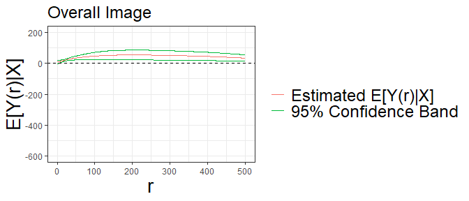

**Figure 4.** Estimated colocalization curve with confidence band for CD8+ T cells around CD8- T cells.

```r
p <- funboot::plot_wildBS_CB(CB_overall)

p +
  labs(
    title = "Overall Image",
    x = "r",
    y = "E[Y(r)|X]"
  ) +
  scale_color_manual(
    name = " ",
    values = c(
      "Estimated Target Curve" = "#F8766D",
      "Confidence Band" = "#00BA38"
    ),
    labels = c(
      "Estimated Target Curve" = "Estimated E[Y(r)|X]",
      "Confidence Band" = "95% Confidence Band"
    ),
    breaks = c("Estimated Target Curve", "Confidence Band")
  ) +
  coord_cartesian(ylim = c(-600, 200)) +
  theme(
    axis.title.y = element_text(size = 20),
    axis.title.x = element_text(size = 20),
    plot.title = element_text(size = 18),
    legend.title = element_text(size = 12),
    legend.text = element_text(size = 18),
    plot.subtitle = element_text(size = 18)
  )
```

The lower bound of the confidence band is positive at all radii, indicating significant colocalization.

**Modeling Colocalization Within Heterogeneous Tissue Regions**

We next demonstrate how to analyze colocalization between these two cell types within regions of the tissue absent of vasculature cells. To do this, we use the spatial covariate $\widehat{L}^{CD8-,Vas}(r)$, where $CD8-$ represents CD8- T cells and $Vas$ represents vasculature cells.

For a given radius $r$, $\widehat{L}^{CD8-,Vas}(r) = 0$ indicates that no vasculature cells are present within radius $r$ of CD8- T cells. We therefore define avascular tissue regions as regions yielding $\widehat{L}^{CD8-,Vas}(r) = 0$. Under this definition, we can estimate the CD8+/CD8- colocalization curve in avascular tissue regions by evaluating the fitted model

$$Y_{ik}(r) = \beta_0(r) + \beta_1(r)\widehat{L}_{ik}^{CD8-,Vas}(r) +
b_{0i}(r) + \epsilon_{ik}(r), \qquad i = 1, \ldots, n, \qquad k = 1,
\ldots, K_i$$

at $\widehat{L}^{CD8-,Vas}(r) = 0$.

The first step is to calculate $\widehat{L}^{CD8-,Vas}(r)$ and merge its values into the dataset:

```r
set.seed(12345)

## Compute \hat{L}_{CD8-,Vas}(r)
spatial_cov_data <- funboot::preprocess_data(
  data = melanoma_data,
  from_cell = "CD8- T cell",
  to_cell = "Vasculature",
  qc_cellcount_cutoff = 20,
  n_perm = 5,
  perm_yn = TRUE,
  r_max = 500,
  inc = 1,
  image_dims = c(0, 1200, 0, 1200),
  summary_function = "L"
)

## Prepare for merge
spatial_cov_data$patient_id <- as.factor(spatial_cov_data$patient_id)
names(spatial_cov_data)[names(spatial_cov_data) == "L_obs"] <- "spatial_cov"
spatial_cov_data <- spatial_cov_data[,!names(spatial_cov_data) %in% c("L_expect", "L_pmean","outcome")]

## Merge and sort results
sumfun_data_full <- merge(
  sumfun_data,
  spatial_cov_data,
  by = c("image_number", "r", "patient_id", "patient_age"),
  all = FALSE
)
sumfun_data_full <- sumfun_data_full[
  order(
    sumfun_data_full$image_number,
    sumfun_data_full$r
  ),
]
```

To evaluate the fitted model at $\widehat{L}^{CD8-,Vas}(r) = 0$, we create a list called `covar_list`, which acts as a design matrix assigning the value 0 to `spatial_cov` at all radii.

```r
covar_list <- list(
  Intercept = rep(1, 501),
  spatial_cov = rep(0, 501)
)
```

We then calculate the desired confidence band, specifying `target`, `form`, `func`, and `covar_list` such that $\theta(r) = \beta_0(r) + \beta_1(r) \times 0$.

```r
CB_avascular <- funboot::wildBS_CB(
  formula = outcome ~ spatial_cov + s(patient_id, bs = "re"),
  data = sumfun_data_full,
  spatial_covars = c("spatial_cov"),
  target = c("Intercept", "spatial_cov"),
  form = c("coef", "term"),
  covar_list = covar_list,
  func = function(Intercept, spatial_cov) {
    Intercept + spatial_cov
  },
  B1 = 10,
  B2 = 10,
  alpha = 0.05,
  re = "patient_id",
  id = "patient_id"
)
```

`funboot::plot_wildBS_CB()` plots the result:

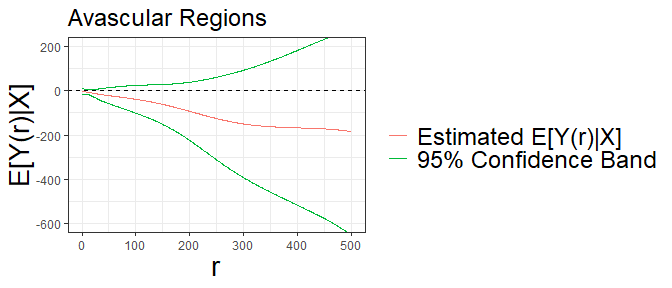

**Figure 5.** Estimated colocalization curve with confidence band for CD8+ T cells around CD8- T cells in avascular regions.

```r
p <- funboot::plot_wildBS_CB(CB_avascular)

p +
  labs(
    title = "Avascular Regions",
    x = "r",
    y = "E[Y(r)|X]"
  ) +
  scale_color_manual(
    name = " ",
    values = c(
      "Estimated Target Curve" = "#F8766D",
      "Confidence Band" = "#00BA38"
    ),
    labels = c(
      "Estimated Target Curve" = "Estimated E[Y(r)|X]",
      "Confidence Band" = "95% Confidence Band"
    ),
    breaks = c("Estimated Target Curve", "Confidence Band")
  ) +
  coord_cartesian(ylim = c(-600, 200)) +
  theme(
    axis.title.y = element_text(size = 20),
    axis.title.x = element_text(size = 20),
    plot.title = element_text(size = 18),
    legend.title = element_text(size = 12),
    legend.text = element_text(size = 18),
    plot.subtitle = element_text(size = 18)
  )
```

In the above, the confidence band shows that the estimated colocalization curve is not significantly different from 0. This indicates that although CD8- and CD8+ T cells showed a net positive colocalization across the full image area, the same pattern is not evident in avascular regions. The representative images in Figure 3 support this conclusion, as the two types of T cells are seen closest together in regions that also contain vasculature.